# VBA

```python
%matplotlib inline
import pandas as pd
import matplotlib.pyplot as plt
import numpy as np
```

Выведем нашу базу (первые 10 строк). Всего 98 команд из 5 чемпионатов.

```python
data = pd.read_csv('vba_data.csv', sep = '_')
data.columns = ['Команда', 'Вратарь', 'ПЗ', 'ПЦЗ', 'ЛЦЗ', 'ЛЗ', 'ПЦП', 'ЛЦП', 'ПП', 'ЛП',
       'ЦАП', 'ФРД', 'Сыгранность', 'Франция', 'Германия', 'Италия', 'Испания',
       'Англия', 'Очки', 'Забитые голы', 'Пропущенные']
data.head(10)
```

|  | Команда | Вратарь | ПЗ | ПЦЗ | ЛЦЗ | ЛЗ | ПЦП | ЛЦП | ПП | ЛП | ... | ФРД | Сыгранность | Франция | Германия | Италия | Испания | Англия | Очки | Забитые голы | Пропущенные |
| --- | --- | --- | --- | --- | --- | --- | --- | --- | --- | --- | --- | --- | --- | --- | --- | --- | --- | --- | --- | --- | --- |
| 0 | ПСЖ | 82 | 81 | 88 | 83 | 79 | 82 | 84 | 84 | 86 | ... | 85 | 3.272727 | 1 | 0 | 0 | 0 | 0 | 96.0 | 102 | 19 |
| 1 | Лион | 82 | 78 | 78 | 80 | 75 | 80 | 76 | 76 | 74 | ... | 72 | 3.545455 | 1 | 0 | 0 | 0 | 0 | 65.0 | 67 | 43 |
| 2 | Монако | 81 | 78 | 74 | 78 | 75 | 82 | 72 | 79 | 74 | ... | 77 | 2.272727 | 1 | 0 | 0 | 0 | 0 | 65.0 | 57 | 50 |
| 3 | Ницца | 70 | 74 | 72 | 75 | 74 | 77 | 72 | 76 | 82 | ... | 78 | 2.636364 | 1 | 0 | 0 | 0 | 0 | 63.0 | 58 | 41 |
| 4 | Лилль | 81 | 76 | 76 | 80 | 75 | 68 | 79 | 74 | 74 | ... | 78 | 2.636364 | 1 | 0 | 0 | 0 | 0 | 60.0 | 39 | 27 |
| 5 | Сент Этьен | 83 | 74 | 78 | 82 | 75 | 76 | 76 | 78 | 74 | ... | 75 | 4.545455 | 1 | 0 | 0 | 0 | 0 | 58.0 | 42 | 37 |
| 6 | Кан | 76 | 71 | 70 | 75 | 72 | 70 | 72 | 74 | 70 | ... | 70 | 3.454545 | 1 | 0 | 0 | 0 | 0 | 54.0 | 39 | 52 |
| 7 | Ренн | 81 | 75 | 78 | 75 | 75 | 76 | 72 | 75 | 79 | ... | 76 | 2.909091 | 1 | 0 | 0 | 0 | 0 | 52.0 | 52 | 54 |
| 8 | Анже | 69 | 70 | 72 | 74 | 70 | 75 | 71 | 76 | 73 | ... | 73 | 2.454545 | 1 | 0 | 0 | 0 | 0 | 50.0 | 40 | 38 |
| 9 | Бастия | 71 | 69 | 74 | 73 | 69 | 70 | 67 | 75 | 74 | ... | 69 | 4.000000 | 1 | 0 | 0 | 0 | 0 | 50.0 | 36 | 42 |

10 rows × 21 columns

Пронормируем характеристики по школе (0, 5), выведем часть базы, относящуюся к чемпионату Англии.

```python
norm = [i*0.05 for i in data['Вратарь'].values]
data['Вратарь'] = norm
norm = [i*0.05 for i in data['ПЗ'].values]
data['ПЗ'] = norm
norm = [i*0.05 for i in data['ПЦЗ'].values]
data['ПЦЗ'] = norm
norm = [i*0.05 for i in data['ЛЦЗ'].values]
data['ЛЦЗ'] = norm
norm = [i*0.05 for i in data['ЛЗ'].values]
data['ЛЗ'] = norm
norm = [i*0.05 for i in data['ПЦП'].values]
data['ПЦП'] = norm
norm = [i*0.05 for i in data['ЛЦП'].values]
data['ЛЦП'] = norm
norm = [i*0.05 for i in data['ПП'].values]
data['ПП'] = norm
norm = [i*0.05 for i in data['ЛП'].values]
data['ЛП'] = norm
norm = [i*0.05 for i in data['ЦАП'].values]
data['ЦАП'] = norm
norm = [i*0.05 for i in data['ФРД'].values]
data['ФРД'] = norm
norm = [float(i) for i in data['Сыгранность'].values]
data['Сыгранность'] = norm
data[data['Англия'] == 1]
```

[output not shown]

20 rows × 21 columns

Сначала рассмотрим в качестве целевой переменной набранные очки:

```python
target = data['Очки'].values
```

Создадим таблицу с признаками:

```python
data_1 = data.drop(['Очки', 'Забитые голы', 'Пропущенные', 'Команда'], axis = 1)
features = data_1.values
data_1
```

|  | Вратарь | ПЗ | ПЦЗ | ЛЦЗ | ЛЗ | ПЦП | ЛЦП | ПП | ЛП | ЦАП | ФРД | Сыгранность | Франция | Германия | Италия | Испания | Англия |
| --- | --- | --- | --- | --- | --- | --- | --- | --- | --- | --- | --- | --- | --- | --- | --- | --- | --- |
| 0 | 4.10 | 4.05 | 4.40 | 4.15 | 3.95 | 4.10 | 4.20 | 4.20 | 4.30 | 4.45 | 4.25 | 3.272727 | 1 | 0 | 0 | 0 | 0 |
| 1 | 4.10 | 3.90 | 3.90 | 4.00 | 3.75 | 4.00 | 3.80 | 3.80 | 3.70 | 4.15 | 3.60 | 3.545455 | 1 | 0 | 0 | 0 | 0 |
| 2 | 4.05 | 3.90 | 3.70 | 3.90 | 3.75 | 4.10 | 3.60 | 3.95 | 3.70 | 4.15 | 3.85 | 2.272727 | 1 | 0 | 0 | 0 | 0 |
| 3 | 3.50 | 3.70 | 3.60 | 3.75 | 3.70 | 3.85 | 3.60 | 3.80 | 4.10 | 3.75 | 3.90 | 2.636364 | 1 | 0 | 0 | 0 | 0 |
| 4 | 4.05 | 3.80 | 3.80 | 4.00 | 3.75 | 3.40 | 3.95 | 3.70 | 3.70 | 3.75 | 3.90 | 2.636364 | 1 | 0 | 0 | 0 | 0 |
| 5 | 4.15 | 3.70 | 3.90 | 4.10 | 3.75 | 3.80 | 3.80 | 3.90 | 3.70 | 3.70 | 3.75 | 4.545455 | 1 | 0 | 0 | 0 | 0 |
| 6 | 3.80 | 3.55 | 3.50 | 3.75 | 3.60 | 3.50 | 3.60 | 3.70 | 3.50 | 3.75 | 3.50 | 3.454545 | 1 | 0 | 0 | 0 | 0 |
| 7 | 4.05 | 3.75 | 3.90 | 3.75 | 3.75 | 3.80 | 3.60 | 3.75 | 3.95 | 3.80 | 3.80 | 2.909091 | 1 | 0 | 0 | 0 | 0 |
| 8 | 3.45 | 3.50 | 3.60 | 3.70 | 3.50 | 3.75 | 3.55 | 3.80 | 3.65 | 3.45 | 3.65 | 2.454545 | 1 | 0 | 0 | 0 | 0 |
| 9 | 3.55 | 3.45 | 3.70 | 3.65 | 3.45 | 3.50 | 3.35 | 3.75 | 3.70 | 3.40 | 3.45 | 4.000000 | 1 | 0 | 0 | 0 | 0 |
| 10 | 3.40 | 3.95 | 3.40 | 3.80 | 3.65 | 3.70 | 3.30 | 3.75 | 3.55 | 3.85 | 3.85 | 2.818182 | 1 | 0 | 0 | 0 | 0 |
| 11 | 3.85 | 3.65 | 3.90 | 3.70 | 3.65 | 3.55 | 3.85 | 3.75 | 3.85 | 3.50 | 3.55 | 4.000000 | 1 | 0 | 0 | 0 | 0 |
| 12 | 4.15 | 3.60 | 4.00 | 3.60 | 3.70 | 3.75 | 4.10 | 3.80 | 3.75 | 3.95 | 3.80 | 3.090909 | 1 | 0 | 0 | 0 | 0 |
| 13 | 3.85 | 3.65 | 3.60 | 3.70 | 3.45 | 3.60 | 3.80 | 3.65 | 3.55 | 3.75 | 3.60 | 2.727273 | 1 | 0 | 0 | 0 | 0 |
| 14 | 3.85 | 3.55 | 3.65 | 3.65 | 3.75 | 3.55 | 3.50 | 3.75 | 3.45 | 3.85 | 3.65 | 3.000000 | 1 | 0 | 0 | 0 | 0 |
| 15 | 3.80 | 3.55 | 3.70 | 3.65 | 3.55 | 3.55 | 3.70 | 3.70 | 3.65 | 3.80 | 3.70 | 3.000000 | 1 | 0 | 0 | 0 | 0 |
| 16 | 3.50 | 3.40 | 3.55 | 3.60 | 3.55 | 3.40 | 3.55 | 3.70 | 3.85 | 3.90 | 3.90 | 3.636364 | 1 | 0 | 0 | 0 | 0 |
| 17 | 3.30 | 3.75 | 3.50 | 3.85 | 3.65 | 3.60 | 3.55 | 3.70 | 3.40 | 3.65 | 3.70 | 2.727273 | 1 | 0 | 0 | 0 | 0 |
| 18 | 3.50 | 3.35 | 3.45 | 3.30 | 3.35 | 3.40 | 3.40 | 3.30 | 3.50 | 3.35 | 3.35 | 3.000000 | 1 | 0 | 0 | 0 | 0 |
| 19 | 3.30 | 2.80 | 3.75 | 3.35 | 3.45 | 3.20 | 3.30 | 3.30 | 3.70 | 3.65 | 3.50 | 3.272727 | 1 | 0 | 0 | 0 | 0 |
| 20 | 4.50 | 4.35 | 4.20 | 4.35 | 4.25 | 4.25 | 4.15 | 4.30 | 4.15 | 4.30 | 4.40 | 5.272727 | 0 | 1 | 0 | 0 | 0 |
| 21 | 4.00 | 4.00 | 4.15 | 4.30 | 3.90 | 3.75 | 4.25 | 4.20 | 4.10 | 4.30 | 4.20 | 3.909091 | 0 | 1 | 0 | 0 | 0 |
| 22 | 4.15 | 3.85 | 3.80 | 4.05 | 3.55 | 3.90 | 3.95 | 4.10 | 3.80 | 3.95 | 4.10 | 2.636364 | 0 | 1 | 0 | 0 | 0 |
| 23 | 4.10 | 3.40 | 3.60 | 3.90 | 3.95 | 3.65 | 4.10 | 3.90 | 4.00 | 3.85 | 4.05 | 2.818182 | 0 | 1 | 0 | 0 | 0 |
| 24 | 4.15 | 3.75 | 4.15 | 4.05 | 3.70 | 3.95 | 3.85 | 3.80 | 3.85 | 3.95 | 4.05 | 4.000000 | 0 | 1 | 0 | 0 | 0 |
| 25 | 4.00 | 3.70 | 3.65 | 3.80 | 3.65 | 3.85 | 3.75 | 3.75 | 3.80 | 3.90 | 3.75 | 2.727273 | 0 | 1 | 0 | 0 | 0 |
| 26 | 3.80 | 3.80 | 3.85 | 3.85 | 3.80 | 3.75 | 3.85 | 3.60 | 3.90 | 3.90 | 3.85 | 2.909091 | 0 | 1 | 0 | 0 | 0 |
| 27 | 4.00 | 3.85 | 4.20 | 4.00 | 4.10 | 3.95 | 4.15 | 4.00 | 4.10 | 3.85 | 4.05 | 3.272727 | 0 | 1 | 0 | 0 | 0 |
| 28 | 4.05 | 3.75 | 3.65 | 3.75 | 3.75 | 3.75 | 3.90 | 3.50 | 3.65 | 3.80 | 3.90 | 2.454545 | 0 | 1 | 0 | 0 | 0 |
| 29 | 3.80 | 3.60 | 3.80 | 3.90 | 3.65 | 3.75 | 3.85 | 3.75 | 3.70 | 3.85 | 3.85 | 2.272727 | 0 | 1 | 0 | 0 | 0 |
| ... | ... | ... | ... | ... | ... | ... | ... | ... | ... | ... | ... | ... | ... | ... | ... | ... | ... |
| 68 | 3.75 | 3.50 | 3.60 | 3.65 | 3.45 | 3.65 | 3.70 | 3.50 | 3.85 | 3.60 | 3.55 | 3.545455 | 0 | 0 | 0 | 1 | 0 |
| 69 | 4.10 | 3.75 | 4.10 | 4.05 | 3.90 | 4.00 | 4.10 | 4.00 | 3.90 | 4.00 | 3.95 | 3.000000 | 0 | 0 | 0 | 1 | 0 |
| 70 | 3.55 | 3.80 | 3.80 | 3.65 | 3.50 | 3.85 | 3.70 | 3.80 | 3.65 | 3.75 | 3.90 | 2.272727 | 0 | 0 | 0 | 1 | 0 |
| 71 | 3.55 | 3.65 | 3.60 | 3.70 | 3.50 | 3.65 | 3.70 | 3.65 | 3.70 | 3.50 | 3.70 | 1.727273 | 0 | 0 | 0 | 1 | 0 |
| 72 | 3.80 | 3.70 | 3.75 | 3.85 | 3.75 | 3.85 | 3.90 | 3.70 | 3.80 | 3.75 | 3.95 | 2.636364 | 0 | 0 | 0 | 1 | 0 |
| 73 | 3.85 | 3.80 | 3.70 | 3.70 | 3.65 | 3.80 | 3.65 | 3.65 | 3.45 | 3.75 | 3.60 | 1.454545 | 0 | 0 | 0 | 1 | 0 |
| 74 | 3.80 | 3.80 | 3.70 | 3.60 | 3.65 | 3.75 | 3.65 | 3.60 | 3.85 | 3.85 | 3.75 | 4.272727 | 0 | 0 | 0 | 1 | 0 |
| 75 | 3.50 | 3.50 | 3.80 | 3.65 | 3.85 | 3.90 | 3.95 | 3.80 | 3.60 | 3.55 | 3.70 | 2.727273 | 0 | 0 | 0 | 1 | 0 |
| 76 | 3.85 | 3.80 | 3.65 | 3.65 | 3.70 | 3.80 | 3.70 | 3.90 | 3.85 | 3.55 | 3.75 | 2.636364 | 0 | 0 | 0 | 1 | 0 |
| 77 | 3.65 | 3.60 | 3.75 | 3.75 | 3.60 | 3.75 | 3.75 | 3.80 | 3.85 | 3.80 | 3.90 | 2.727273 | 0 | 0 | 0 | 1 | 0 |
| 78 | 3.90 | 3.60 | 3.90 | 3.90 | 3.80 | 4.05 | 3.80 | 3.95 | 3.75 | 3.80 | 3.95 | 2.454545 | 0 | 0 | 0 | 0 | 1 |
| 79 | 4.30 | 3.85 | 4.15 | 4.20 | 4.00 | 3.95 | 4.25 | 4.30 | 3.45 | 4.40 | 4.10 | 3.909091 | 0 | 0 | 0 | 0 | 1 |
| 80 | 4.25 | 3.95 | 4.10 | 4.10 | 3.90 | 3.80 | 4.00 | 4.00 | 4.15 | 3.85 | 4.10 | 4.000000 | 0 | 0 | 0 | 0 | 1 |
| 81 | 4.20 | 4.00 | 4.20 | 3.95 | 3.95 | 4.00 | 4.25 | 4.00 | 4.30 | 4.30 | 4.40 | 4.000000 | 0 | 0 | 0 | 0 | 1 |
| 82 | 4.35 | 3.75 | 4.15 | 3.95 | 3.35 | 4.10 | 3.80 | 4.15 | 4.25 | 3.90 | 3.45 | 4.272727 | 0 | 0 | 0 | 0 | 1 |
| 83 | 3.80 | 3.45 | 4.05 | 3.85 | 3.90 | 3.85 | 3.65 | 3.90 | 3.90 | 3.80 | 3.75 | 2.272727 | 0 | 0 | 0 | 0 | 1 |
| 84 | 3.90 | 3.75 | 4.00 | 3.95 | 3.70 | 3.80 | 3.80 | 3.85 | 3.90 | 4.15 | 3.85 | 3.181818 | 0 | 0 | 0 | 0 | 1 |
| 85 | 3.90 | 4.00 | 3.95 | 3.90 | 3.85 | 4.00 | 3.75 | 4.00 | 4.20 | 4.10 | 4.15 | 2.090909 | 0 | 0 | 0 | 0 | 1 |
| 86 | 3.10 | 3.60 | 4.00 | 3.85 | 3.75 | 3.80 | 3.90 | 4.00 | 3.95 | 4.00 | 3.75 | 3.090909 | 0 | 0 | 0 | 0 | 1 |
| 87 | 4.30 | 4.00 | 4.10 | 4.20 | 4.10 | 4.30 | 4.15 | 4.15 | 4.15 | 4.40 | 4.25 | 4.818182 | 0 | 0 | 0 | 0 | 1 |
| 88 | 3.70 | 4.05 | 3.85 | 4.05 | 4.10 | 4.00 | 3.95 | 3.85 | 3.85 | 4.00 | 4.10 | 4.181818 | 0 | 0 | 0 | 0 | 1 |
| 89 | 3.90 | 3.70 | 3.90 | 4.05 | 3.70 | 3.85 | 3.75 | 3.75 | 3.85 | 3.95 | 3.95 | 2.909091 | 0 | 0 | 0 | 0 | 1 |
| 90 | 3.80 | 3.85 | 3.60 | 3.70 | 3.60 | 3.60 | 3.55 | 3.85 | 3.75 | 3.85 | 3.80 | 2.181818 | 0 | 0 | 0 | 0 | 1 |
| 91 | 3.95 | 3.30 | 3.75 | 3.85 | 3.90 | 3.90 | 3.25 | 3.75 | 3.75 | 3.65 | 3.95 | 3.090909 | 0 | 0 | 0 | 0 | 1 |
| 92 | 3.70 | 3.80 | 3.90 | 3.70 | 3.75 | 3.80 | 4.00 | 3.90 | 3.85 | 3.75 | 3.65 | 2.181818 | 0 | 0 | 0 | 0 | 1 |
| 93 | 3.80 | 3.60 | 3.55 | 3.60 | 3.55 | 3.70 | 3.65 | 3.65 | 3.95 | 3.75 | 3.45 | 2.909091 | 0 | 0 | 0 | 0 | 1 |
| 94 | 3.70 | 3.55 | 3.70 | 3.80 | 3.70 | 3.75 | 3.75 | 3.85 | 3.90 | 3.90 | 3.90 | 1.818182 | 0 | 0 | 0 | 0 | 1 |
| 95 | 3.40 | 3.85 | 3.85 | 3.85 | 3.45 | 3.90 | 3.80 | 3.75 | 4.00 | 3.95 | 3.80 | 2.909091 | 0 | 0 | 0 | 0 | 1 |
| 96 | 3.75 | 3.65 | 3.55 | 3.80 | 3.70 | 3.50 | 3.75 | 3.70 | 3.75 | 3.80 | 3.90 | 2.909091 | 0 | 0 | 0 | 0 | 1 |
| 97 | 3.65 | 3.65 | 3.85 | 3.70 | 3.80 | 3.65 | 3.70 | 3.80 | 3.75 | 3.65 | 3.80 | 2.454545 | 0 | 0 | 0 | 0 | 1 |

98 rows × 17 columns

Попробуем обучить линейную регрессию, для получения возможности прогнозировать результат команды по заданным характеристикам. Выведем ошибку:

```python
from sklearn.cross_validation import train_test_split
from sklearn.linear_model import LinearRegression
from sklearn.metrics import mean_squared_error
X_train, X_test, y_train, y_test = train_test_split(
    features, target, test_size=0.2, random_state=6632)
linreg = LinearRegression()
def test_regressor(reg):
    reg.fit(X_train, y_train)
    print("Train RMSE:", (mean_squared_error(y_train, reg.predict(X_train)))**(1/2))
    print("Test RMSE:", (mean_squared_error(y_test, reg.predict(X_test)))**(1/2))
test_regressor(linreg)
```

```
Train RMSE: 6.92032698227
Test RMSE: 6.52025088422
```

Посмотрим как введение регуляризатора повлияет на ошибку (первый график - L1(Лассо), второй - L2(Ridge):

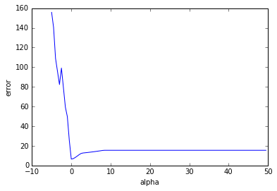

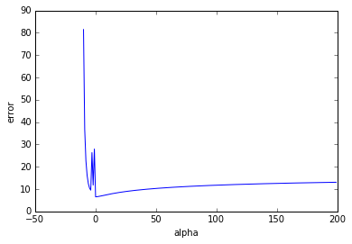

```python
import warnings
warnings.filterwarnings("ignore")
from sklearn.linear_model import Ridge, Lasso
from sklearn.tree import DecisionTreeRegressor
from sklearn.ensemble import RandomForestRegressor
def rmse_on_alpha(reg_class, alpha_values):
    train_mse = []
    test_mse = []
    for alpha in alpha_values:
        reg = reg_class(alpha=alpha)
        reg.fit(X_train, y_train)

        train_mse.append((mean_squared_error(y_train, reg.predict(X_train)))**(1/2))
        test_mse.append((mean_squared_error(y_test, reg.predict(X_test)))**(1/2))

    plt.figure()
    plt.plot(alpha_values, test_mse)
    plt.xlabel('alpha')
    plt.ylabel('error')
rmse_on_alpha(Lasso, np.arange(-5, 50, 0.5))
rmse_on_alpha(Ridge, np.arange(-10, 200.0, 1.0))
```

Вывод: добавлять регуляризатор не имеет смысла. Теперь рассмотрим алгоритмы решающих деревьев и случайного леса (в зависимости от паарметра max_depth):

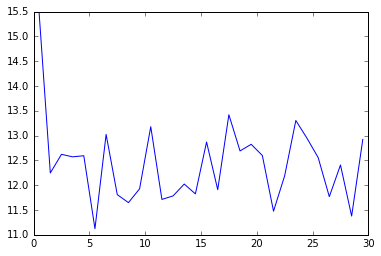

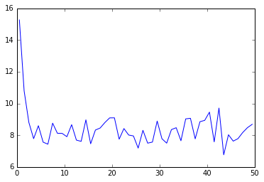

```python
def reg1(reg_class, alpha):
    test_rmse = []
    for i in alpha:
        reg = reg_class(max_depth = i)
        reg.fit(X_train, y_train)
        test_rmse.append((mean_squared_error(y_test, reg.predict(X_test)))**(1/2))
    plt.figure()
    plt.plot(alpha, test_rmse)
reg1(DecisionTreeRegressor, np.arange(0.5, 30, 1))
reg1(RandomForestRegressor, np.arange(0.5, 50, 1))
```

Алгоритм случайного леса дает более хорошие результаты. Посмотрим на ошибку:

```python
reg = RandomForestRegressor(max_depth = 22)
reg.fit(X_train, y_train)
print((mean_squared_error(y_test, reg.predict(X_test)))**(1/2))
```

```
9.01867305471
```

И тем не менее обычная линейная регрессия оказалась лучше. Поэтому будем использовать именно ее в качестве предсказания.

Теперь посмотрим как наша команда выступила бы в чемпионате Франции (первое значение - очки Уфы, второе - Санкт-Петербургского Зенита:

```python
reg = LinearRegression()
reg.fit(features, target)
print(reg.coef_)
def vanga(characteristics):
    norm = characteristics
    norm_1 = [i*0.05 for i in norm[:11]]
    last_norm = norm_1 + norm[11:]
    print(reg.predict(np.asarray(last_norm))[0])
vanga([63, 67, 65, 69, 62, 64, 72, 63, 66, 71, 67, 2, 1, 0, 0, 0, 0])
vanga([77, 76, 76, 78, 77, 74, 80, 84, 81, 82, 80, 4, 1, 0, 0, 0, 0])
```

```
[ 10.10812472   2.1301281    5.7037802   16.55525466   3.47498641
   9.12749205   4.40743073  20.41044233  14.08925206   9.65438941
  -8.48163971   0.167015     7.78683002   0.46612029   0.469869
  -2.15925413  -6.56356518]
14.8124398184
74.4953684702
```

К сожалению, Уфа вылетела бы из чемпионата, заняв последнее место. А вот Зенит уверенно занял бы вторую строчку (по реальным результатам сезона 2015 - 2016) Теперь посмотрим на остальные чемпионаты. Германия:

```python
vanga([63, 67, 65, 69, 62, 64, 72, 63, 66, 71, 67, 2, 0, 1, 0, 0, 0])
vanga([77, 76, 76, 78, 77, 74, 80, 84, 81, 82, 80, 4, 0, 1, 0, 0, 0])
```

```
7.49173009191
67.1746587437
```

Уфа снова не у дел. А вот Зенит третий. Италия:

```python
vanga([63, 67, 65, 69, 62, 64, 72, 63, 66, 71, 67, 2, 0, 0, 1, 0, 0])
vanga([77, 76, 76, 78, 77, 74, 80, 84, 81, 82, 80, 4, 0, 0, 1, 0, 0])
```

```
7.49547879627
67.1784074481
```

Чемпионат Италии и Германии не сильно отличаются, как мы видим из результатов. Зенит - четвертый. Уфа - в Серию В (второй итальянский дивизион). Испания:

```python
vanga([63, 67, 65, 69, 62, 64, 72, 63, 66, 71, 67, 2, 0, 0, 0, 1, 0])
vanga([77, 76, 76, 78, 77, 74, 80, 84, 81, 82, 80, 4, 0, 0, 0, 1, 0])
```

```
4.86635566631
64.5492843181
```

Все еще хуже для Уфы. Сильное отставание от зоны выживания и позорный вылет. Зент - четвертый. Англия:

```python
vanga([63, 67, 65, 69, 62, 64, 72, 63, 66, 71, 67, 2, 0, 0, 0, 0, 1])
vanga([77, 76, 76, 78, 77, 74, 80, 84, 81, 82, 80, 4, 0, 0, 0, 0, 1])
```

```
0.462044614525
60.1449732663
```

Итог: чемпионат России - самое приемлемое место для Уфы. Здесь хотя бы есть шансы не вылететь из турнира (что и героически продемонстрировала наша команда в двух последних сезонах). Верим!